# Basic statistics

## 4.3 ANOVA/ANCOVA

We can compare the differences in means between multiple (≥ 2) groups. For example, the savings ratio between the five continents can be compared:

1. Based on an analysis of variance (ANOVA) between groups. Note that the coefficient estimate and significance level of each group is compared against the intercept, which is defined by alphabetical order (in this example, Africa)
2. Based on the analysis of covariance (ANCOVA) between groups. ANCOVA is a blend of ANOVA and linear regression, which statistically controls for the effects of other continuous variable (e.g. `dpi`) that are not of primary interest.

```r
model <- aov(sr ~ continent, data = LifeCycleSavings) # ANOVA
summary.lm(model)
```

```
##
## Call:
## aov(formula = sr ~ continent, data = LifeCycleSavings)
##
## Residuals:
##      Min       1Q   Median       3Q      Max
## -10.3021  -2.0500   0.3556   2.1000  11.3000
##
## Coefficients:
##                   Estimate Std. Error t value Pr(>|t|)
## (Intercept)        10.9400     1.8602   5.881 5.04e-07 ***
## continentAmericas  -3.7356     2.1311  -1.753   0.0866 .
## continentAsia      -1.1400     2.4356  -0.468   0.6420
## continentEurope     0.6321     2.0907   0.302   0.7638
## continentOceania    0.1100     3.4801   0.032   0.9749
## ---
## Signif. codes:  0 '***' 0.001 '**' 0.01 '*' 0.05 '.' 0.1 ' ' 1
##
## Residual standard error: 4.16 on 44 degrees of freedom
##   (1 observation deleted due to missingness)
## Multiple R-squared:  0.1887, Adjusted R-squared:  0.115
## F-statistic: 2.559 on 4 and 44 DF,  p-value: 0.05173
```

```r
model <- aov(sr ~ continent + dpi, data = LifeCycleSavings) # ANCOVA
summary.lm(model)
```

```
##
## Call:
## aov(formula = sr ~ continent + dpi, data = LifeCycleSavings)
##
## Residuals:
##      Min       1Q   Median       3Q      Max
## -10.3458  -1.9905   0.2849   2.1321  10.9703
##
## Coefficients:
##                     Estimate Std. Error t value Pr(>|t|)
## (Intercept)       10.8342824  1.8895049   5.734  8.9e-07 ***
## continentAmericas -3.9408796  2.1919761  -1.798   0.0792 .
## continentAsia     -1.1746300  2.4581846  -0.478   0.6352
## continentEurope    0.0711454  2.4104787   0.030   0.9766
## continentOceania  -0.4978399  3.7316721  -0.133   0.8945
## dpi                0.0003739  0.0007777   0.481   0.6332
## ---
## Signif. codes:  0 '***' 0.001 '**' 0.01 '*' 0.05 '.' 0.1 ' ' 1
##
## Residual standard error: 4.196 on 43 degrees of freedom
##   (1 observation deleted due to missingness)
## Multiple R-squared:  0.1931, Adjusted R-squared:  0.09922
## F-statistic: 2.057 on 5 and 43 DF,  p-value: 0.08953
```

Importantly, ANOVA/ANCOVA also makes assumptions about the data (see Section 4.2). If assumptions are violated, for example, the (non-parametric) Kruskal–Wallis test may be used instead of ANOVA (it is an extension of the Mann–Whitney U test, which only allows for comparison between two groups). See [statsmethods.net](https://www.statmethods.net/stats/anovaAssumptions.html) for more details on how to test assumptions for ANOVA/ANCOVA.

Diagnostic plots may be used to examine whether assumptions are met. Click [here](https://arc.lib.montana.edu/book/statistics-with-r-textbook/item/57) to read more about interpreting these plots.

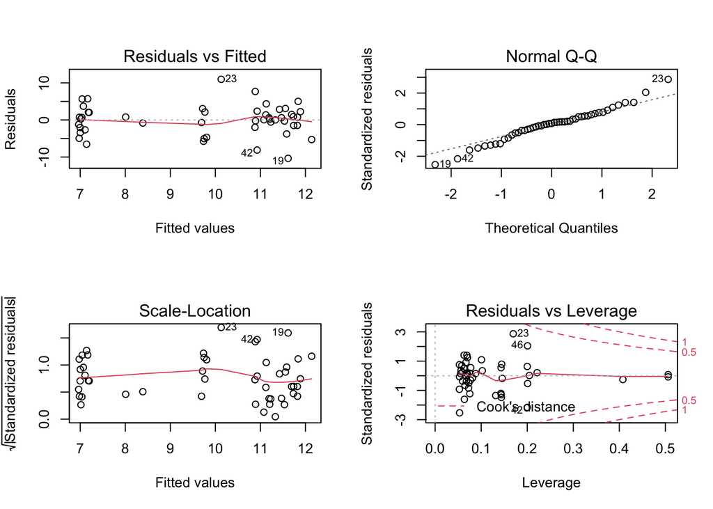

```r
par(mfrow=c(2,2)) # combine four plots into one
plot(model)
```

# 5 Further resources

- [Understanding p-values through simulation](https://rpsychologist.com/pvalue/)
- [Understanding maximum likelihood](https://rpsychologist.com/likelihood/)
- [Statistical power and significance testing](https://rpsychologist.com/d3/nhst/)
- [Confidence intervals](https://rpsychologist.com/d3/ci/)
- [Correlations](https://rpsychologist.com/correlation/)
- [t-distribution](https://rpsychologist.com/d3/tdist/)
- [P-value distribution](https://rpsychologist.com/d3/pdist/)
- [Cohen’s d](https://rpsychologist.com/cohend/)
- [Linear regression](https://mlu-explain.github.io/linear-regression/)

Copyright © 2022 Song, Xiao Ping

[^1]: *Type I Error* (alpha): Rejecting the null hypothesis when actually true (scientific consensus = 0.05)
[^2]: *Type II error* (beta): Accepting the null hypothesis when it is false (scientific consensus = 0.2)